# Capital, Labour and Justice

Lecture 1: Gender and the pay gap

Dr David Chivers

Political Economy

## Important: How to Read

### How much should I read?

- Ask yourself when reading: what am I trying to get out of this?
- Are you reading for understanding, argument, evidence or criticism?
- Some reading you will skim over, some you will read in detail, some you won’t read
- It is up to you to determine what is and isn’t important

### Understanding the Reading

- You are not expected to understand the methods/maths of something you have not been taught
- Read the introduction and conclusion, then examine the main evidence needed for the question

## Outline

### Capital, Labour and Justice

- Lecture 1: Gender and the pay gap
- Lecture 2: Discrimination
- Lecture 3: Technology, AI and work
- Lecture 4: Fairness
- Lecture 5: Redistribution

## Gender Pay Gap

[figure not shown]

## Women in Work

## Women in Work Over Time

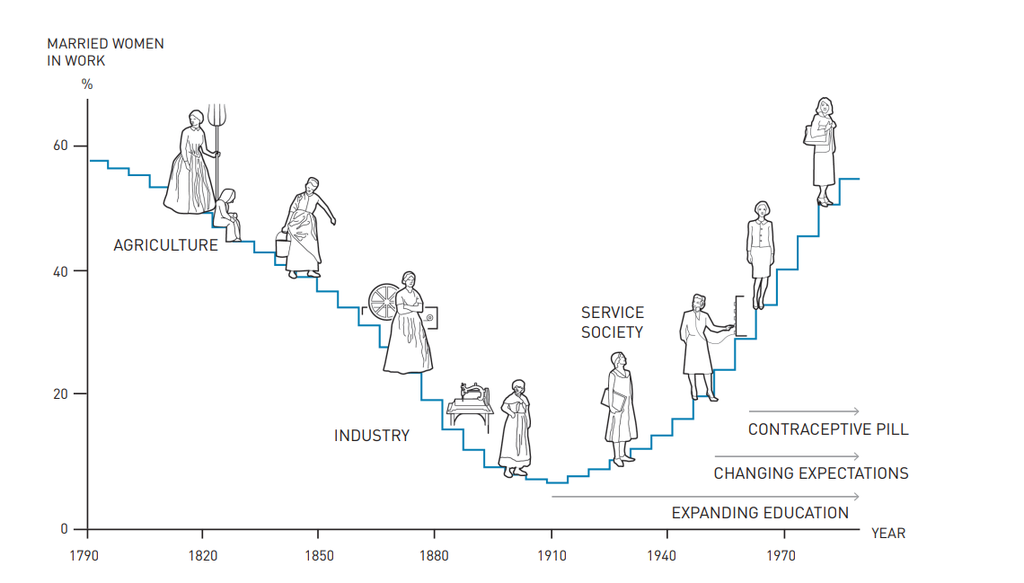

## Women’s Work Over Time

- How did women’s participation in employment change over time?
- Before the 20<sup>th</sup>century women would work in subsistence farming
- The earnings gap narrowed during the industrial revolution (1820– 1850)
- During the 20th century, high-income countries employment opportunities for women increased due to:
- 1. Expansion of white-collar work,
- 2. Technological change (both at work and in the home)
- 3. Changes in education (e.g. expansion of secondary schooling)
- **BUT** institutional barriers stilled existed
- “Marriage bars” prevented married women from working

## Gender Pay Gap Over Time

- Due to the rise in white collar work, the wage gap fell
- However, wage discrimination increased
- By 1940, more than 50% of the earnings gap in office work could not be accounted for by individual productivity
- How is this possible?

### Promotion and Pay

- Promotion played a key part in the earnings gap and loyalty/commitment were important for promotion.
- As women were expected to have lower job tenure than men, employers would use gender as a “signal” for promotion (see next lecture on discrimination)
- This earnings gap remained stable for the early part of the 20<sup>th</sup> century despite increases in GDP and the female participation rate.

## Gender Pay Gap Over Time

- The earnings gap narrowed during the latter half of the 20<sup>th</sup> century. But why did it take so long?
- **Expectations:** Women’s expectations about future labour force participation determine investment in education (Goldin, 2006)
- In 1900s: girl’s expectations about future prospects were accurate, if based on what their mother did
- In 1950-60s this would have been inaccurate.
- **The Pill:**It was not until the late 1960s that the pill was available to unmarried women, but laws varied by state (before this you had to be married)
- In the early 1970s many states reduced the age from 21 to 18 and passed access to family planning laws without need for parental consent.
- Goldin and Katz (2002) used this state and time variation show access to the pill meant woman married later and lowered cost of long-term education for women.
- These changes were not driven by family planning concerns but a rather to reduce the age of conscription for the ongoing Vietnam War

## Women In Education

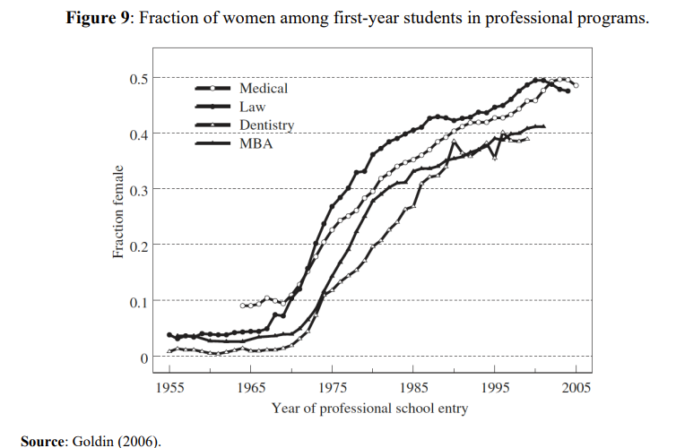

## The Motherhood Penalty

## The Motherhood Penalty

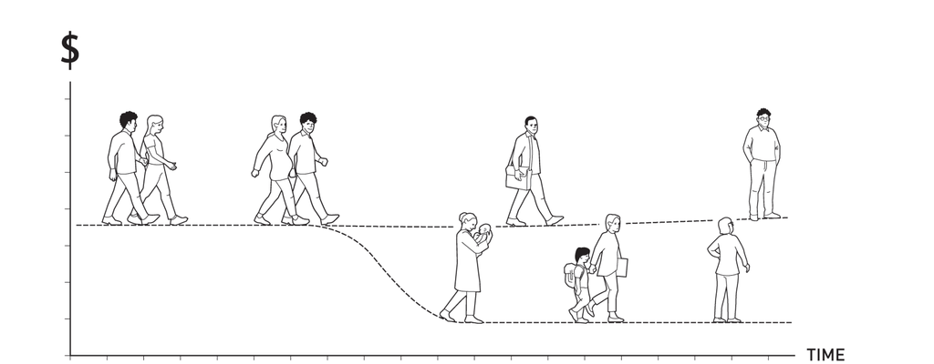

## The Motherhood Penalty

- Differences in education and occupation have become less important to the raw gender gap, over time
- Within-occupation gaps, however, has become more important.

### Childbirth

- Within-occupations gaps emerge and increase during childbirth (Bertrand, Goldin, and Katz, 2010)

### Why is this the case?

- Time away from the labour market (human capital)
- Returning to work at reduced hours
- Part time work offers less pay pro rata as full-time work (Goldin, 2014)

## The Motherhood Penalty

### Hours worked

- The gender pay gap would shrink if firms did not pay more for individuals who work certain hours
- The gender pay gap is larger for occupations with more time pressure and contact with others
- This has been partially resolved in occupations like technology, science and health
- But not in corporate, financial and the legal world

### Motherhood Penalty Interventions

- Paternity leave doesn’t have much of an impact
- Mixed evidence on publicly provided childcare (Eckhoff and Nix, 2022) and (Karademir et al 2024)
- Working from home? (Harrington and Kahn, 2023)
- We will discuss other types of interventions, such as quotas, next lecture

## The Gender Pay Gap

## Gender Pay Gap

- Does **Google** underpay its female employees?
- Google’s response: If you take location, tenure, job role, level and performance into consideration, women’s pay is basically identical to that of men.
- Is this evidence that gender discrimination does not exist?

## Gender Pay Gap

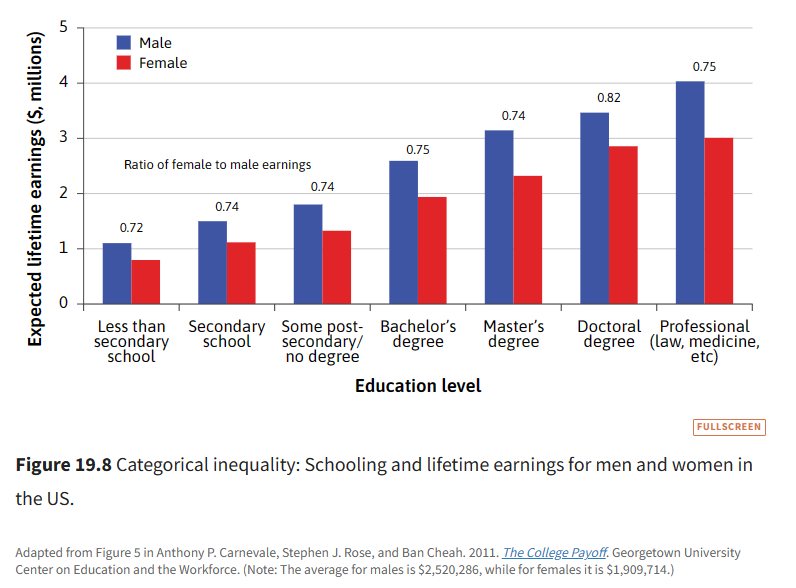

## An Introduction to DAGs

## An Intro to DAGs

- A DAG (Directed Acyclic Graph) is a graphical representation of chain of causal effects.
- Direct causality: D → Y
- Indirect causality: D → X → Y
- They are theoretically informed by e.g. economic theory
- Importantly, an absence of an arrow implies you think there is no causal relationship in the data

## An Intro to DAGs

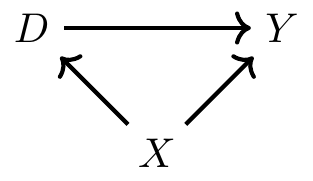

- There is a causal relationship D → Y
- But there is also a non-causal backdoor path D ← X → Y.
- We call X a confounder. If we do not control for it in a regression we would bias our results.
- For example, D = Discrimination, Y = Income, X = Education Level

## An Intro to DAGs

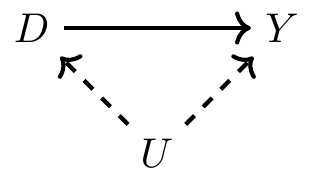

- Dashed lines represent an unobservable characteristic and is a backdoor pathway i.e. one we cannot see in the data
- For example, D = Discrimination, Y = Income, U = Innate Talent
- In order to establish causality, we want to close all backdoor pathways.

## Collider Bias

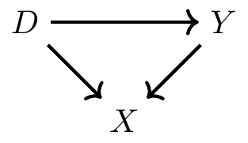

- There is a causal relationship D → Y
- But there is also a non-causal backdoor path D → X ← Y.
- But notice, both D and Y are now pointing in the opposite direction: they are colliding on X
- Colliders are like the opposite of Confounders. If you control for them, it actually biases your results!

## Collider Bias

- Let’s say you want to find out if there is a correlation between talent for acting and attractiveness.
- But here is no theoretical reason why this would be the case!

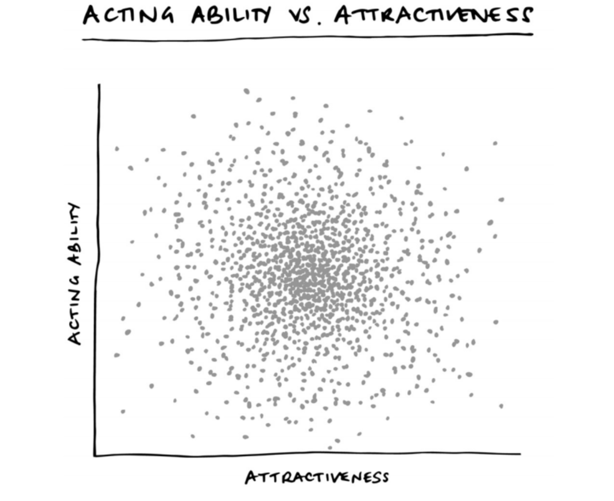

## Collider Bias

- But if you controlled for the person being a professional actor you might (wrongly) end up with negative correlation!
- If you’re spectacularly attractive, you don’t need to be all that good at acting to make it in Hollywood (and vice versa).

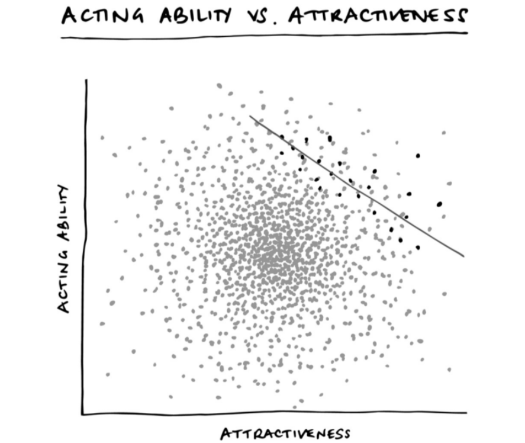

## Gender Discrimination

- What if discrimination is affecting “location, tenure, job role, level and performance” etc?
- F = Female
- D = Discrimination
- Y = Income
- A= Unobserved Ability
- O = Occupation
- There is a causal relationship between discrimination and D → Y
- BUT there is an indirect causal relationship mediated by Occupation D → O → Y

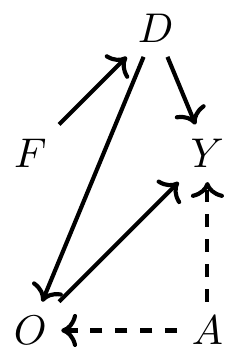

## Gender Discrimination

- The path D → O → Y says discrimination affects which jobs women hold. As a result, women have worse jobs and then paid less.
- Controlling for occupation allows us to compare men and women in similar jobs but causes a problem:
- The path D → O ← A → Y contains a collider on occupation.
- As unobserved ability and discrimination collides on occupation, controlling for occupation actually biases our results!
- We need to also control for unobserved ability somehow to close down this backdoor path.

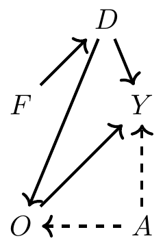

## Results

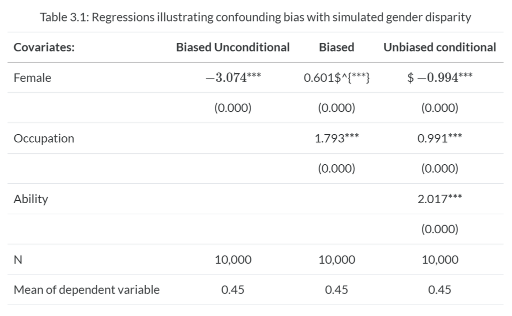

## The Gender-Equality Paradox

## The Gender-Equality Paradox

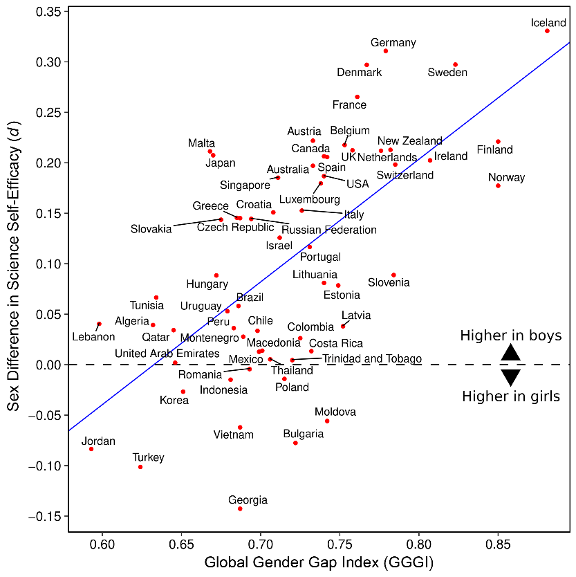

## The Gender-Equality Paradox

### Criticisms:

- Measurement issues
- Correlation does not equal causation
- Stereotypes could explain it e.g. “math is not for girls”
- Ecological fallacy: conclusions about individuals cannot be made from group-level data…
  - Even if correlation exists at national level, this does not tell us whether women - who experience greater gender equity - are less likely to choose STEM education.

## Summary

- The history of women in work is U-shaped.
- The gender wage gap has decreased during the latter half of the 20<sup>th</sup> century but took a long time to get there.
- The within-occupation pay gap is now the largest contributor to the gender wage-gap, driven by the motherhood penalty.
- Finding out the causal effects of discrimination is difficult due to collider bias.
- See [Talis](https://durham.rl.talis.com/modules/econ2301.html) for **reading list**.

Note: not all citations in this lecture are listed there.